# About Me

Sammi Rosser

21/04/2021

## Who Am I?

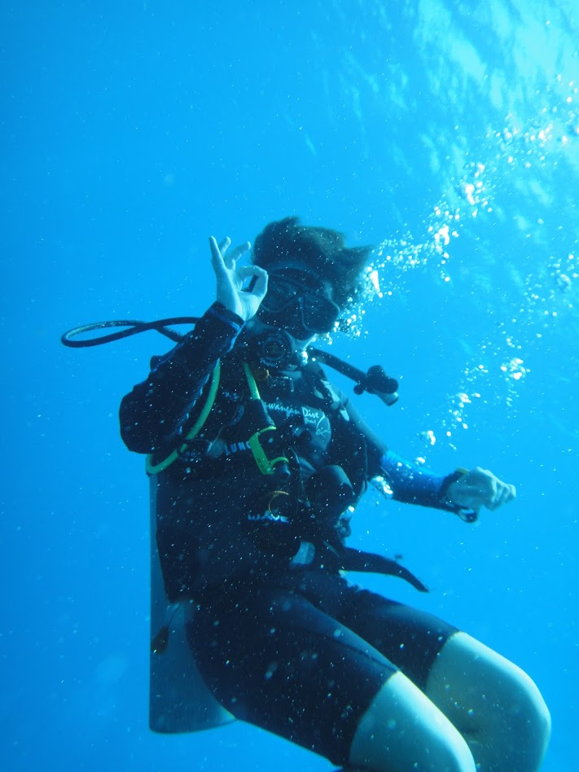

Diving Photo

**Education:**

MSc Health Data Science - University of Exeter - **IN PROGRESS** - Graduating 2021

BA Biological Science - Lady Margaret Hall, Oxford - 2014

More informally…

- More [DataCamp certificates](https://www.datacamp.com/profile/sammirosser) than you can shake a stick at (52 as of April 2021).

**Outside of work**

I think you can tell a lot about me by my diving journey.

I’m not a great swimmer. Therefore, before starting university, it seemed like a great idea to work in a factory for a year so I could afford to spend six weeks scuba diving off a tropical island.

So, at 18, I paid the money I’d saved, packed a rucksack that was almost bigger than me, and got on a plane to Indonesia.

[figure not shown]

I became a PADI qualified rescue diver (after obtaining my open water and advanced open water qualifications). I failed my first attempt after not locating the missing diver, and narrowly avoided being rescued on my second attempt after one fin fell off and I had to swim against a current to get back to shore while carrying an extra set of diving gear. Honestly, don’t expect me to rescue you in anything larger than a pond.

I wasn’t a natural diver. I struggled with every aspect of it.

I bloody loved it.

I bring this attitude to everything else I have tackled in my life. My studies, my jobs - I will throw myself into it with a smile on my face. I believe you can learn anything and do anything with the right attitude and, more importantly, the right people around you.